# Sommaire

## le lien entre l’âge et les catégories des livres achetés.

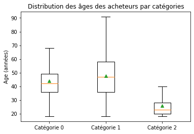

```python
# Categories les plus achetees par age:
categ = achats["categ"].unique()
categ_age = {categ: achats.loc[achats["categ"]==categ, "age"] for categ in categ}

# Graphique:
plt.boxplot([
    categ_age[0],
    categ_age[1],
    categ_age[2]]
    ,labels=["Catégorie 0", "Catégorie 1", "Catégorie 2"],showmeans=True, showfliers=False)
plt.ylabel("Age (années)")
plt.title("Distribution des âges des acheteurs par catégories")
plt.savefig("assets/graphiques/14.1 Distribution des ages des acheteurs par catégories.png")
plt.show()
```

```python
# Lien entre age et categorie achetees:
#print(type(categ_age[0].values))
print(st.kruskal(categ_age[0], categ_age[1], categ_age[2]))
```

```
KruskalResult(statistic=79350.86927924873, pvalue=0.0)
```

**Le test de Kruskal Wallis**, est non paramétrique, les groupes doivent contenir plus de cinq individus. p-val < 0,01 **on rejette l'hypothèse nulle selon laquelle il n'y aurait pas de différence entre l'âge median d'achat par catégorie.** Kruskal est un test de rang.

- le **test des rangs** signés de Wilcoxon est une **alternative non-paramétrique au test de Student** pour des échantillons appariés. Le test s'intéresse à un paramètre de position : la médiane, le but étant de tester s'il existe un changement sur la médiane.
  - **Des échantillons appariés** sont des échantillons identiques, c'est à dire des échantillons **composés d'individus possédant les mêmes caractéristiques**. La ou les caractéristiques faisant l'objet de l'appariement peuvent être variables (âge, sexe, etc..).

# Lien entre le panier moyen et l'age

```python
panier_moyen = achats['price'].sum()/achats['session_id'].count()
panier_moyen
```

```
17.45234505367037
```

```python
panierMoyen_age = achats.groupby(["age"]).agg({'price':'sum','session_id':'count'})
```

```python
panierMoyen_age["lien"] = panierMoyen_age["price"]/panierMoyen_age["session_id"]
panierMoyen_age.reset_index(inplace=True)
```

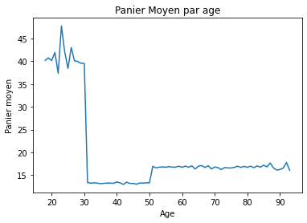

```python
# test correlation : corrélation linéaire te corrélarion de Pearson
plt.plot(panierMoyen_age['age'],panierMoyen_age['lien'])
plt.xlabel("Age")
plt.ylabel("Panier moyen")
plt.title("Panier Moyen par age")
plt.savefig("assets/graphiques/16 Panier moyen par age.png")
```

```python
panierMoyen_age.corr(method='pearson')
```

|  | age | price | session_id | lien |
| --- | --- | --- | --- | --- |
| age | 1.000000 | -0.778862 | -0.533705 | -0.547907 |
| price | -0.778862 | 1.000000 | 0.830352 | 0.249527 |
| session_id | -0.533705 | 0.830352 | 1.000000 | -0.267356 |
| lien | -0.547907 | 0.249527 | -0.267356 | 1.000000 |

```python
# corrresation négative => comportement par tranche d'ages => anova
```

```python
X = "age_rank" # qualitative
Y = "lien" # quantitative

sous_echantillon = panierMoyen_age
```

```python
sous_echantillon["age_rank"] = pd.cut(x= sous_echantillon["age"], bins=[17,30,50,100], include_lowest=False, ordered=True)
```

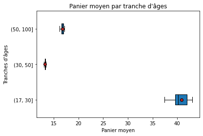

```python
modalites = sous_echantillon[X].unique()
groupes = []
for m in modalites:
    groupes.append(sous_echantillon[sous_echantillon[X]==m][Y])

# Propriétés graphiques (pas très importantes)
medianprops = {'color':"black"}
meanprops = {'marker':'o', 'markeredgecolor':'black',
            'markerfacecolor':'firebrick'}

plt.boxplot(groupes, labels=modalites, showfliers=False, medianprops=medianprops,
            vert=False, patch_artist=True, showmeans=True, meanprops=meanprops)
plt.title("Panier moyen par tranche d'âges")
plt.xlabel("Panier moyen")
plt.ylabel("Tranches d'âges")
plt.savefig("assets/graphiques/17 Panier moyen par tranche age.png")
plt.show()
```

```python
X = "age_rank" # qualitative
Y = "lien" # quantitative

def eta_squared(x,y):
    moyenne_y = y.mean()
    classes = []
    for classe in x.unique():
        yi_classe = y[x==classe]
        classes.append({'ni': len(yi_classe),
                        'moyenne_classe': yi_classe.mean()})
    SCT = sum([(yj-moyenne_y)**2 for yj in y])
    SCE = sum([c['ni']*(c['moyenne_classe']-moyenne_y)**2 for c in classes])
    return SCE/SCT

eta_squared(sous_echantillon[X],sous_echantillon[Y])
```

```
0.9881431123434874
```

```python
#forte correlation en fonction des tranches d'age choisies
```